# Group-Time ATTs

Sam Harper

2021-11-09

## Standard Two-Way Fixed Effects

First, let’s read in the Stata dataset, and create a smaller version with just the variables of interest for looking at skilled birth attendance:

| district | sba_birth | txdel | time | dist_id | p_id | group |
| --- | --- | --- | --- | --- | --- | --- |
| Kaliua DC | 0 | 0 | 1 | 1 | 237 | 2 |
| Kaliua DC | 1 | 1 | 5 | 1 | 2168 | 2 |
| Kaliua DC | 0 | 1 | 5 | 1 | 6723 | 2 |
| Kaliua DC | 0 | 0 | 1 | 1 | 2269 | 2 |
| Kaliua DC | 1 | 1 | 5 | 1 | 5084 | 2 |
| Kaliua DC | 1 | 1 | 5 | 1 | 2058 | 2 |

Using this data, let’s now run the standard TWFE analysis that is the workhorse of most DD applications with differential treatment timing.
$$y_{sba} = \alpha + \beta*txdel + \gamma_{district} + \delta_{time} + \epsilon$$

```
## OLS estimation, Dep. Var.: sba_birth
## Observations: 5,555
## Fixed-effects: district: 8,  time: 5
## Standard-errors: Clustered (district)
##       Estimate Std. Error t value Pr(>|t|)
## txdel  0.05976   0.037325 1.60105   0.1534
## ---
## Signif. codes:  0 '***' 0.001 '**' 0.01 '*' 0.05 '.' 0.1 ' ' 1
## RMSE: 0.425631     Adj. R2: 0.057514
##                  Within R2: 5.313e-4
```

Because the treatment is assigned at the cluster level and we aren’t adjusting for any covariates, we can also analyze this at the cluster level. Next let’s aggregate up to the district level. Here is a look at the dataset:

| district | dist_id | time | tsba | tpop | psba | txdel | group |
| --- | --- | --- | --- | --- | --- | --- | --- |
| Kaliua DC | 1 | 1 | 409 | 705 | 0.580 | 0 | 2 |
| Kaliua DC | 1 | 2 | 49 | 73 | 0.671 | 1 | 2 |
| Kaliua DC | 1 | 3 | 63 | 77 | 0.818 | 1 | 2 |
| Kaliua DC | 1 | 4 | 9 | 10 | 0.900 | 1 | 2 |
| Kaliua DC | 1 | 5 | 94 | 114 | 0.825 | 1 | 2 |
| Nzega DC | 2 | 1 | 465 | 634 | 0.733 | 0 | 3 |
| Nzega DC | 2 | 2 | 60 | 76 | 0.789 | 0 | 3 |
| Nzega DC | 2 | 3 | 43 | 57 | 0.754 | 1 | 3 |
| Nzega DC | 2 | 4 | 9 | 10 | 0.900 | 1 | 3 |
| Nzega DC | 2 | 5 | 88 | 101 | 0.871 | 1 | 3 |
| Nzega TC | 3 | 1 | 165 | 182 | 0.907 | 0 | 5 |
| Nzega TC | 3 | 2 | 13 | 13 | 1.000 | 0 | 5 |
| Nzega TC | 3 | 3 | 12 | 14 | 0.857 | 0 | 5 |
| Nzega TC | 3 | 4 | 4 | 5 | 0.800 | 0 | 5 |
| Nzega TC | 3 | 5 | 21 | 24 | 0.875 | 1 | 5 |
| Sikonge DC | 4 | 1 | 310 | 374 | 0.829 | 0 | 5 |
| Sikonge DC | 4 | 2 | 49 | 53 | 0.925 | 0 | 5 |
| Sikonge DC | 4 | 3 | 23 | 27 | 0.852 | 0 | 5 |
| Sikonge DC | 4 | 4 | 4 | 5 | 0.800 | 0 | 5 |
| Sikonge DC | 4 | 5 | 44 | 52 | 0.846 | 1 | 5 |
| Tabora MC | 5 | 1 | 540 | 614 | 0.879 | 0 | 4 |
| Tabora MC | 5 | 2 | 53 | 59 | 0.898 | 0 | 4 |
| Tabora MC | 5 | 3 | 39 | 44 | 0.886 | 0 | 4 |
| Tabora MC | 5 | 4 | 6 | 6 | 1.000 | 1 | 4 |
| Tabora MC | 5 | 5 | 82 | 86 | 0.953 | 1 | 4 |
| Urambo DC | 6 | 1 | 158 | 193 | 0.819 | 0 | 2 |
| Urambo DC | 6 | 2 | 15 | 17 | 0.882 | 1 | 2 |
| Urambo DC | 6 | 3 | 20 | 25 | 0.800 | 1 | 2 |
| Urambo DC | 6 | 4 | 2 | 3 | 0.667 | 1 | 2 |
| Urambo DC | 6 | 5 | 25 | 30 | 0.833 | 1 | 2 |
| Uyui DC | 7 | 1 | 338 | 514 | 0.658 | 0 | 4 |
| Uyui DC | 7 | 2 | 60 | 81 | 0.741 | 0 | 4 |
| Uyui DC | 7 | 3 | 29 | 57 | 0.509 | 0 | 4 |
| Uyui DC | 7 | 4 | 6 | 10 | 0.600 | 1 | 4 |
| Uyui DC | 7 | 5 | 63 | 81 | 0.778 | 1 | 4 |
| Igunga DC | 8 | 1 | 522 | 821 | 0.636 | 0 | 3 |
| Igunga DC | 8 | 2 | 67 | 89 | 0.753 | 0 | 3 |
| Igunga DC | 8 | 3 | 40 | 68 | 0.588 | 1 | 3 |
| Igunga DC | 8 | 4 | 15 | 20 | 0.750 | 1 | 3 |
| Igunga DC | 8 | 5 | 94 | 131 | 0.718 | 1 | 3 |

You can see that we are aggregating up to the district level, and how we have the total population (`tpop`) and the total number of births with a skilled attendant (`tsba`), as well as the proportion by district.

Now, we can also fit the TWFE model to this aggregate data, controlling for district fixed effects and survey wave.

```
## OLS estimation, Dep. Var.: psba
## Observations: 40
## Fixed-effects: district: 8,  time: 5
## Standard-errors: Clustered (district)
##       Estimate Std. Error t value Pr(>|t|)
## txdel  0.05976   0.039958 1.49557  0.17842
## ---
## Signif. codes:  0 '***' 0.001 '**' 0.01 '*' 0.05 '.' 0.1 ' ' 1
## RMSE: 0.466034     Adj. R2: 0.826702
##                  Within R2: 0.058009
```

The estimates from these two models are identical (SEs are very minimally different), which is just to say that it is fine to work with the aggregate data to estimate the impact of the intervention (absent control for covariates):

|  | Individual | Aggregate |
| --- | --- | --- |
| txdel | 0.060 | 0.060 |
|  | (0.037) | (0.040) |
| Num.Obs. | 5555 | 40 |
| Std.Errors | by: district | by: district |
| FE: district | X | X |
| FE: time | X | X |

## Callaway/Sant’Anna Approach

Okay so we have the traditional DD estimate of around a 6 percentage point increase in SBA. Now let’s look at the Callaway-Sant’Anna DD estimate. Since the CS DD approach functions by aggregating different kinds of group-time DDs, we can also aggregate up to the group level, since we have 2 groups being treated at each wave post-baseline. Let’s define a new variable `group` that indicates the time at which each group was *first* treated. So for Kaliua DC and Urambo DC that were the first groups to be treated post-baseline (what we will call time=2), they are assigned a value of `group=2`, and so on for the other groups. Meanwhile, we are still aggregating up the number of births with SBA and the total population of each group.

| group | time | tsba | tpop | psba | txdel |
| --- | --- | --- | --- | --- | --- |
| 2 | 1 | 567 | 898 | 0.631 | 0 |
| 2 | 2 | 64 | 90 | 0.711 | 1 |
| 2 | 3 | 83 | 102 | 0.814 | 1 |
| 2 | 4 | 11 | 13 | 0.846 | 1 |
| 2 | 5 | 119 | 144 | 0.826 | 1 |
| 3 | 1 | 987 | 1455 | 0.678 | 0 |
| 3 | 2 | 127 | 165 | 0.770 | 0 |
| 3 | 3 | 83 | 125 | 0.664 | 1 |
| 3 | 4 | 24 | 30 | 0.800 | 1 |
| 3 | 5 | 182 | 232 | 0.784 | 1 |
| 4 | 1 | 878 | 1128 | 0.778 | 0 |
| 4 | 2 | 113 | 140 | 0.807 | 0 |
| 4 | 3 | 68 | 101 | 0.673 | 0 |
| 4 | 4 | 12 | 16 | 0.750 | 1 |
| 4 | 5 | 145 | 167 | 0.868 | 1 |
| 5 | 1 | 475 | 556 | 0.854 | 0 |
| 5 | 2 | 62 | 66 | 0.939 | 0 |
| 5 | 3 | 35 | 41 | 0.854 | 0 |
| 5 | 4 | 8 | 10 | 0.800 | 0 |
| 5 | 5 | 65 | 76 | 0.855 | 1 |

Now, just to get a look at what we are comparing when we run the group-time DDs, let’s reshape this data to wide (just to see it):

| group | psba_t1 | psba_t2 | psba_t3 | psba_t4 | psba_t5 | tpop_t1 | tpop_t2 | tpop_t3 | tpop_t4 | tpop_t5 |
| --- | --- | --- | --- | --- | --- | --- | --- | --- | --- | --- |
| 2 | 0.631 | 0.711 | 0.814 | 0.846 | 0.826 | 898 | 90 | 102 | 13 | 144 |
| 3 | 0.678 | 0.770 | 0.664 | 0.800 | 0.784 | 1455 | 165 | 125 | 30 | 232 |
| 4 | 0.778 | 0.807 | 0.673 | 0.750 | 0.868 | 1128 | 140 | 101 | 16 | 167 |
| 5 | 0.854 | 0.939 | 0.854 | 0.800 | 0.855 | 556 | 66 | 41 | 10 | 76 |

Note that we can see the core pieces that are going to contribute to the DD estimates, which are the outcomes in each group and the total population sizes.

Okay, now let’s estimate the impact using the CS DD method:

```r
# Use not-yet-treated as comparison group
atts_cs <- did::att_gt(yname = "psba", # name of the LHS variable
                       tname = "time", # name of the time variable
                       idname = "dist_id", # name of the id variable
                       gname = "group", # name of the first treatment period
                       data = d_sba, # name of the data
                       xformla = NULL,
                       weightsname = "tpop",
                       est_method = "reg", # estimation method.
                       control_group = "notyettreated", # set the control group
                       bstrap = TRUE, # if TRUE compute boostrapped SE
                       biters = 1000, # number of boostrap interations
                       print_details = FALSE, # if TRUE, print detailed results
                       panel = FALSE) # panel or repeated cross-sectional
summary(atts_cs)
```

A summary of the estimates, SEs, and 95% CIs (based on 1000 bootstrapped replications) is below:

| term | group | time | estimate | std.error | conf.low | conf.high |
| --- | --- | --- | --- | --- | --- | --- |
| ATT(2,2) | 2 | 2 | 0.011 | 0.097 | -0.210 | 0.232 |
| ATT(2,3) | 2 | 3 | 0.260 | 0.136 | -0.050 | 0.570 |
| ATT(2,4) | 2 | 4 | 0.269 | 0.119 | -0.002 | 0.540 |
| ATT(3,2) | 3 | 2 | 0.045 | 0.088 | -0.155 | 0.246 |
| ATT(3,3) | 3 | 3 | 0.018 | 0.136 | -0.291 | 0.328 |
| ATT(3,4) | 3 | 4 | 0.170 | 0.062 | 0.028 | 0.312 |
| ATT(4,2) | 4 | 2 | -0.062 | 0.113 | -0.319 | 0.194 |
| ATT(4,3) | 4 | 3 | -0.048 | 0.144 | -0.375 | 0.278 |
| ATT(4,4) | 4 | 4 | 0.130 | 0.275 | -0.494 | 0.755 |

One thing that is immediately different from the TWFE method is that we get an entire suite of ATTs for each group and time period, which allows us to see:

- heterogeneity across both groups treated at different times (e.g., the ATT in the first year of treatment is much smaller for the group first treated at time=2 (ATT(2,2) = 0.01) relative to the estimated effect in the first year of treatment for the group first treated at time 4, i.e., ATT(4,4) = 0.13, though both estimates are imprecise); and
- as well as different times for each treatment group, e.g.., the impact at time 3 for the group first treated at time 2 is 0.26 relative to 0.01 for the first year of treatment. Again, there is a lot of uncertainty, but there is a suggestion of a delayed treatment effect.

Let’s take a quick detour to understand where these estimates are coming from.

## Group Time ATTs

The core of the CS estimator is the group-time ATT. They define groups based on when they were first treated and use as controls either groups that are never treated, not-yet-treated, or both. In our case, since we don’t have any groups that are never treated, we have to use the not-yet-treated groups as controls for each 2x2 DD. The key difference, of course, is that we *do not* use any groups that have already been treated to estimate any of the group-time DDs. This was the key idea that Bacon and others showed in ‘decomposing’ the OLS TWFE DD estimate.

### Group 2

The basic idea of the group-time ATTs is to estimate a series of ATTs for each group $G$ that is treated at time $T$. So if we wanted to estimate the ATT at time=2 for the group that is first treated at time=2, we calculate the ‘long’ difference, i.e., post minus pre for the treated group ($G=2$) and the difference for all groups *not already treated* for the same period. Thus, the groups we are comparing to estimate ATT(2,2) are:

| group | time1 | time2 | time3 | time4 | time5 |
| --- | --- | --- | --- | --- | --- |
| 2 | 0.631 | 0.711 | 0.814 | 0.846 | 0.826 |
| 3 | 0.678 | 0.770 | 0.664 | 0.800 | 0.784 |
| 4 | 0.778 | 0.807 | 0.673 | 0.750 | 0.868 |
| 5 | 0.854 | 0.939 | 0.854 | 0.800 | 0.855 |

Note:  
Red = treated, Gray = untreated

If we take the population-weighted average SBA proportions for these two groups, we get 0.011, which is exactly what the CS DiD table above showed for ATT(2,2).

| g22 | time1 | time2 | Long diff | ATT_2_2 |
| --- | --- | --- | --- | --- |
| 0 | 0.745 | 0.814 | 0.069 | NA |
| 1 | 0.631 | 0.711 | 0.080 | 0.011 |

Now, we can ask about how the effect in Group 2 changes with time after the intervention. The ATT(2,3) asks about the estimated treatment effect at time 3 ($t=3$) for the group that was first treated at time 2 ($g=2$). To get this estimate, we now create a similar 2x2 table but are using time 3 as the ‘post’ estimate. But note here that, since group 3 ($G=3$) is treated at time 3, we don’t want to include it as a part of our control group, we that means we restrict our control comparison to only those groups that are **not** treated by time 3. So we are comparing:

| group | time1 | time2 | time3 | time4 | time5 |
| --- | --- | --- | --- | --- | --- |
| 2 | 0.631 | 0.711 | 0.814 | 0.846 | 0.826 |
| 3 | 0.678 | 0.770 | 0.664 | 0.800 | 0.784 |
| 4 | 0.778 | 0.807 | 0.673 | 0.750 | 0.868 |
| 5 | 0.854 | 0.939 | 0.854 | 0.800 | 0.855 |

Note:  
Red = treated, Gray = untreated

And we get:

| g23 | time1 | time3 | Long diff | ATT_2_3 |
| --- | --- | --- | --- | --- |
| 0 | 0.803 | 0.725 | -0.078 | NA |
| 1 | 0.631 | 0.814 | 0.182 | 0.26 |

We can of course extend our view of how the treatment effect evolves for Group 2 by calculating the effect of being treated at time 4 for the group that was first treated at time 2, i.e., ATT(2,4). This is comparing the first *pre-intervention* period for group 2, which is at time 1, and the estimate of SBA at time 4:

| group | time1 | time2 | time3 | time4 | time5 |
| --- | --- | --- | --- | --- | --- |
| 2 | 0.631 | 0.711 | 0.814 | 0.846 | 0.826 |
| 3 | 0.678 | 0.770 | 0.664 | 0.800 | 0.784 |
| 4 | 0.778 | 0.807 | 0.673 | 0.750 | 0.868 |
| 5 | 0.854 | 0.939 | 0.854 | 0.800 | 0.855 |

Note:  
Red = treated, Gray = untreated

Note that the control group here also changes, since at $t=4$ group 4 has now been treated, so we exclude them from the control group for this comparison. And the estimate is:

| g24 | time1 | time4 | Long diff | ATT_2_4 |
| --- | --- | --- | --- | --- |
| 0 | 0.854 | 0.800 | -0.054 | NA |
| 1 | 0.631 | 0.846 | 0.215 | 0.269 |

### Group 3

Now, what about the groups that are first treated at time 3, i.e., ($t=3$)? Since we actually have more than one pre-period for this group, we can also see whether there is some evidence of non-parallel trends by looking at, for example, the ATT(3,2), which is the effect of being treated at **time=2** for the group that is first treated at time 3. In essence, we are comparing the pre-intervention ‘long difference’ between $t=1$ and $t=2$ for the group eventually treated at time 3 with the same long difference among the controls:

| group | time1 | time2 | time3 | time4 | time5 |
| --- | --- | --- | --- | --- | --- |
| 2 | 0.631 | 0.711 | 0.814 | 0.846 | 0.826 |
| 3 | 0.678 | 0.770 | 0.664 | 0.800 | 0.784 |
| 4 | 0.778 | 0.807 | 0.673 | 0.750 | 0.868 |
| 5 | 0.854 | 0.939 | 0.854 | 0.800 | 0.855 |

Note:  
Red = treated, Gray = untreated

The estimate of the ATT(3,2) is:

| g32 | time1 | time2 | Long diff | ATT_3_2 |
| --- | --- | --- | --- | --- |
| 0 | 0.803 | 0.85 | 0.046 | NA |
| 1 | 0.678 | 0.77 | 0.091 | 0.045 |

Now for the treatment effect at time 3 for the groups first treated at time 3 we are comparing:

| group | time1 | time2 | time3 | time4 | time5 |
| --- | --- | --- | --- | --- | --- |
| 2 | 0.631 | 0.711 | 0.814 | 0.846 | 0.826 |
| 3 | 0.678 | 0.770 | 0.664 | 0.800 | 0.784 |
| 4 | 0.778 | 0.807 | 0.673 | 0.750 | 0.868 |
| 5 | 0.854 | 0.939 | 0.854 | 0.800 | 0.855 |

Note:  
Red = treated, Gray = untreated

The estimate of the ATT(3,3) is:

| g33 | time2 | time3 | Long diff | ATT_3_3 |
| --- | --- | --- | --- | --- |
| 0 | 0.85 | 0.725 | -0.124 | NA |
| 1 | 0.77 | 0.664 | -0.106 | 0.018 |

The groups for comparison for the estimated treatment effect at time 4 for the groups first treated at time 3 now also need to exclude group 4, since it has received the treatment at time 4, but note also that the ‘pre-intervention’ period is still ($t=2$) since group 3 was actually treated at time 3. So, we care comparing:

| group | time1 | time2 | time3 | time4 | time5 |
| --- | --- | --- | --- | --- | --- |
| 2 | 0.631 | 0.711 | 0.814 | 0.846 | 0.826 |
| 3 | 0.678 | 0.770 | 0.664 | 0.800 | 0.784 |
| 4 | 0.778 | 0.807 | 0.673 | 0.750 | 0.868 |
| 5 | 0.854 | 0.939 | 0.854 | 0.800 | 0.855 |

Note:  
Red = treated, Gray = untreated

The estimate of the ATT(3,4) is:

| g34 | time2 | time4 | Long diff | ATT_3_4 |
| --- | --- | --- | --- | --- |
| 0 | 0.939 | 0.8 | -0.139 | NA |
| 1 | 0.770 | 0.8 | 0.030 | 0.17 |

### Group 4

| group | time1 | time2 | time3 | time4 | time5 |
| --- | --- | --- | --- | --- | --- |
| 2 | 0.631 | 0.711 | 0.814 | 0.846 | 0.826 |
| 3 | 0.678 | 0.770 | 0.664 | 0.800 | 0.784 |
| 4 | 0.778 | 0.807 | 0.673 | 0.750 | 0.868 |
| 5 | 0.854 | 0.939 | 0.854 | 0.800 | 0.855 |

Note:  
Red = treated, Gray = untreated

Again, taking the population-weighted estimate for the control group and the estimates for Group 4, we can calculate the ATT at time 2 for the group first treated at time 4, i.e., ATT(4,2):

| g42 | time1 | time2 | Long diff | ATT_4_2 |
| --- | --- | --- | --- | --- |
| 0 | 0.727 | 0.818 | 0.091 | NA |
| 1 | 0.778 | 0.807 | 0.029 | -0.062 |

As you might expect, we now make the same progression for the addition ATTs for the the group first treated at time 4. First, for the next ATT for the pre-intervention period we want the treatment effect at time 3 for the group that is first treated at time 4. That means comparing only Groups 4 and 5 (since group 3 is treated at time 3, it has to be excluded from the control population):

| group | time1 | time2 | time3 | time4 | time5 |
| --- | --- | --- | --- | --- | --- |
| 2 | 0.631 | 0.711 | 0.814 | 0.846 | 0.826 |
| 3 | 0.678 | 0.770 | 0.664 | 0.800 | 0.784 |
| 4 | 0.778 | 0.807 | 0.673 | 0.750 | 0.868 |
| 5 | 0.854 | 0.939 | 0.854 | 0.800 | 0.855 |

Note:  
Red = treated, Gray = untreated

And the resulting ATT(4,3) is:

| g43 | time2 | time3 | Long diff | ATT_4_3 |
| --- | --- | --- | --- | --- |
| 0 | 0.939 | 0.854 | -0.086 | NA |
| 1 | 0.807 | 0.673 | -0.134 | -0.048 |

Finally, the last ATT we can estimate is the effect of being treated at time 4 for the group that is first treated at time 4. Again, we can only compare groups 4 and 5 here, since every other group has already been treated. So we are comparing:

| group | time1 | time2 | time3 | time4 | time5 |
| --- | --- | --- | --- | --- | --- |
| 2 | 0.631 | 0.711 | 0.814 | 0.846 | 0.826 |
| 3 | 0.678 | 0.770 | 0.664 | 0.800 | 0.784 |
| 4 | 0.778 | 0.807 | 0.673 | 0.750 | 0.868 |
| 5 | 0.854 | 0.939 | 0.854 | 0.800 | 0.855 |

Note:  
Red = treated, Gray = untreated

And the resulting ATT(4,4) is:

| g44 | time3 | time4 | Long diff | ATT_4_4 |
| --- | --- | --- | --- | --- |
| 0 | 0.854 | 0.80 | -0.054 | NA |
| 1 | 0.673 | 0.75 | 0.077 | 0.13 |

## Weighted ATTs

Instead of taking a weighted average estimate of the ATT with more-or-less arbitrary weights derived from the TWFE OLS approach. The CS DD approch considers several different ways of combining the group-time ATTs we calculated above.

### Simple Average

The most straightforward way of getting a *single* estimate of the ATT from the CS approach is just to weight each of the group-time ATTs by population size:

```
##
## Call:
## aggte(MP = atts_cs, type = "simple")
##
## Reference: Callaway, Brantly and Pedro H.C. Sant'Anna.  "Difference-in-Differences with Multiple Time Periods." Forthcoming at the Journal of Econometrics <https://arxiv.org/abs/1803.09015>, 2020.
##
##
##     ATT    Std. Error     [ 95%  Conf. Int.]
##  0.1348        0.0706    -0.0037      0.2732
##
##
## ---
## Signif. codes: `*' confidence band does not cover 0
##
## Control Group:  Not Yet Treated,  Anticipation Periods:  0
## Estimation Method:  Outcome Regression
```

We can compare this with the estimate we got from the TWFE approach, which was 0.06 with a 95% CI of -0.02 to 0.14. Obviously, this aggregate estimate can hide considerable heterogeneity, but we can also look at other ways of examining heterogeneity in the ATTs.

### Group-specific ATTs

One question we might ask is whether each of our treated groups, which were treated at different times, may have exhibited different treatment effects. We could look at each group’s average (population-weighted) ATT:

```
##
## Call:
## aggte(MP = atts_cs, type = "group")
##
## Reference: Callaway, Brantly and Pedro H.C. Sant'Anna.  "Difference-in-Differences with Multiple Time Periods." Forthcoming at the Journal of Econometrics <https://arxiv.org/abs/1803.09015>, 2020.
##
##
## Overall summary of ATT’s based on group/cohort aggregation:
##     ATT    Std. Error     [ 95%  Conf. Int.]
##  0.1282        0.0948    -0.0576      0.3139
##
##
## Group Effects:
##  Group Estimate Std. Error [95% Simult.  Conf. Band]
##      2   0.1802     0.0798        0.0149      0.3456 *
##      3   0.0941     0.0694       -0.0498      0.2380
##      4   0.1304     0.2749       -0.4394      0.7002
## ---
## Signif. codes: `*' confidence band does not cover 0
##
## Control Group:  Not Yet Treated,  Anticipation Periods:  0
## Estimation Method:  Outcome Regression
```

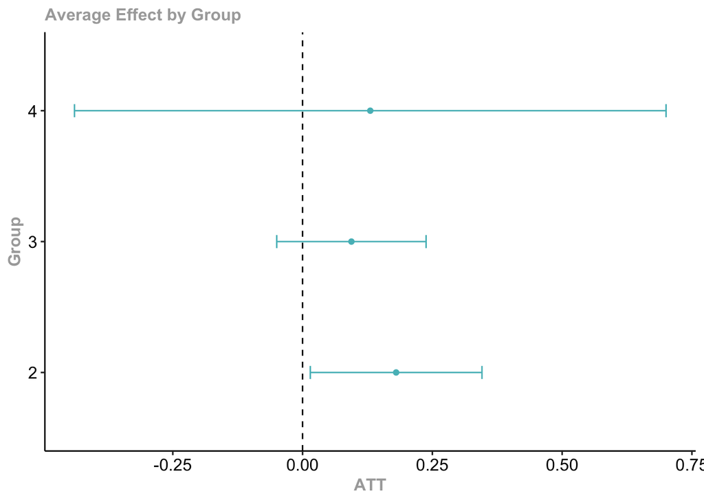

From this we can see that the point estimates range from 0.09 to 0.18, though the group first treated at time 4 clearly has much greater uncertainty, which makes sense given the relatively short follow-up time for this group.

But we can also look at how the average effects change over time, by looking at *dynamic* ATTs.

### Dynamic ATTs

```
##
## Call:
## aggte(MP = atts_cs, type = "dynamic")
##
## Reference: Callaway, Brantly and Pedro H.C. Sant'Anna.  "Difference-in-Differences with Multiple Time Periods." Forthcoming at the Journal of Econometrics <https://arxiv.org/abs/1803.09015>, 2020.
##
##
## Overall summary of ATT’s based on event-study/dynamic aggregation:
##     ATT    Std. Error     [ 95%  Conf. Int.]
##  0.1755        0.0651      0.048       0.303 *
##
##
## Dynamic Effects:
##  Event time Estimate Std. Error [95% Simult.  Conf. Band]
##          -2  -0.0624     0.1193       -0.3278      0.2030
##          -1   0.0043     0.0835       -0.1815      0.1902
##           0   0.0529     0.1068       -0.1847      0.2906
##           1   0.2045     0.0589        0.0734      0.3355 *
##           2   0.2691     0.1193        0.0035      0.5347 *
## ---
## Signif. codes: `*' confidence band does not cover 0
##
## Control Group:  Not Yet Treated,  Anticipation Periods:  0
## Estimation Method:  Outcome Regression
```

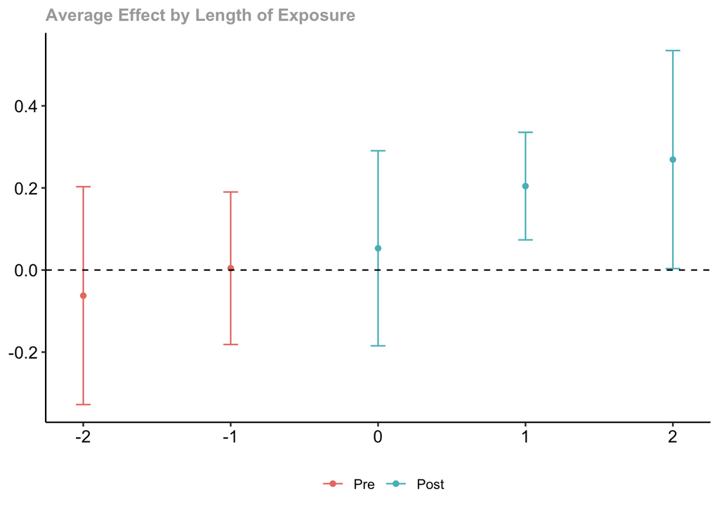

These effects are based on length of exposure to the intervention and allow us to see whether the interventions impacts are sustained.

### Calendar Time ATTs

Finally, one could also aggregate the ATTs not by length of exposure, but by calendar time, looking at whether there is heterogeneity by time period.

```
##
## Call:
## aggte(MP = atts_cs, type = "calendar")
##
## Reference: Callaway, Brantly and Pedro H.C. Sant'Anna.  "Difference-in-Differences with Multiple Time Periods." Forthcoming at the Journal of Econometrics <https://arxiv.org/abs/1803.09015>, 2020.
##
##
## Overall summary of ATT’s based on calendar time aggregation:
##     ATT    Std. Error     [ 95%  Conf. Int.]
##  0.1017        0.0698    -0.0351      0.2385
##
##
## Time Effects:
##  Time Estimate Std. Error [95% Simult.  Conf. Band]
##     2   0.0112     0.0971       -0.1985      0.2208
##     3   0.1112     0.1280       -0.1653      0.3876
##     4   0.1826     0.0702        0.0311      0.3341 *
## ---
## Signif. codes: `*' confidence band does not cover 0
##
## Control Group:  Not Yet Treated,  Anticipation Periods:  0
## Estimation Method:  Outcome Regression
```

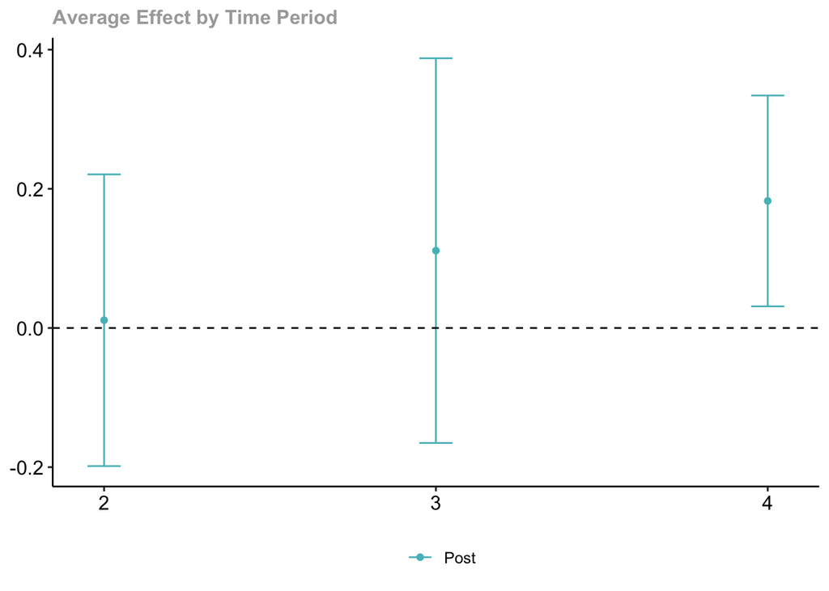

## Standard Errors

| Group | Time | Panel Asym | Panel Boot | Panel Bootc | Repeated XS Asym | Repeated XS Boot | Repeated XS Bootc |
| --- | --- | --- | --- | --- | --- | --- | --- |
| 2 | 2 | 0.009 | 0.009 | 0.009 | 0.011 | 0.011 | 0.011 |
| 2 | 3 | 0.226 | 0.226 | 0.226 | 0.260 | 0.260 | 0.260 |
| 2 | 4 | 0.273 | 0.273 | 0.273 | 0.269 | 0.269 | 0.269 |
| 3 | 2 | 0.027 | 0.027 | 0.027 | 0.045 | 0.045 | 0.045 |
| 3 | 3 | 0.017 | 0.017 | 0.017 | 0.018 | 0.018 | 0.018 |
| 3 | 4 | 0.189 | 0.189 | 0.189 | 0.170 | 0.170 | 0.170 |
| 4 | 2 | -0.044 | -0.044 | -0.044 | -0.062 | -0.062 | -0.062 |
| 4 | 3 | -0.053 | -0.053 | -0.053 | -0.048 | -0.048 | -0.048 |
| 4 | 4 | 0.155 | 0.155 | 0.155 | 0.130 | 0.130 | 0.130 |

And the differences in standard errors across different methods of constructing SEs and assumed study designs:

| Group | Time | Panel Asym | Panel Boot | Panel Bootc | Repeated XS Asym | Repeated XS Boot | Repeated XS Bootc |
| --- | --- | --- | --- | --- | --- | --- | --- |
| 2 | 2 | 0.018 | 0.020 | 0.020 | 0.091 | 0.090 | 0.025 |
| 2 | 3 | 0.073 | 0.081 | 0.081 | 0.130 | 0.136 | 0.073 |
| 2 | 4 | 0.115 | 0.118 | 0.118 | 0.085 | 0.096 | 0.121 |
| 3 | 2 | 0.029 | 0.029 | 0.029 | 0.082 | 0.084 | 0.039 |
| 3 | 3 | 0.071 | 0.091 | 0.091 | 0.130 | 0.137 | 0.095 |
| 3 | 4 | 0.043 | 0.048 | 0.048 | 0.052 | 0.063 | 0.035 |
| 4 | 2 | 0.027 | 0.032 | 0.032 | 0.112 | 0.109 | 0.033 |
| 4 | 3 | 0.077 | 0.080 | 0.080 | 0.143 | 0.148 | 0.032 |
| 4 | 4 | 0.008 | 0.008 | 0.008 | 0.187 | 0.275 | 0.003 |

Okay, so the ATTs are identical when using either the aggregate or the individual level data, as long as you specify that the data should be treated as repeated cross sections.

## Summary

Okay, there is a lot to unpack here, but the bottom line is that the TWFE approach to estimating DD in this context probably introduces bias (I tried to work a bit on the Goodman-Bacon decomposition, but it is a bit hard to sort out in the context of weights like we have). Regardless of how we aggregate the group time ATTs, it seems clear that our estimate is somewhere in the range of 0.10 to 0.20, which is higher than the TWFE estimate, though probably not statistically distinguishable.